# R graphics for bioinformatics

## Frequency polygon — ggplot2

```r
ggplot(mpg, aes(hwy)) + geom_freqpoly(binwidth = 2.5)
```

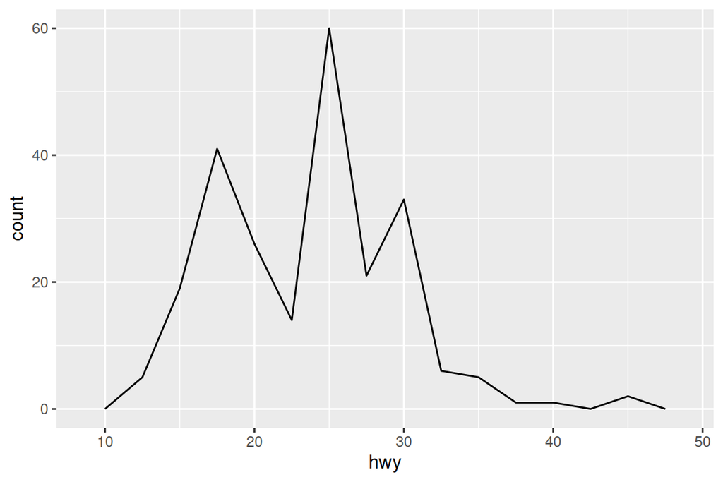

## Frequency polygon — tidyplots

No native verb, use the escape hatch.

```r
mpg |>
  tidyplot(x = hwy, width = NA, height = NA) |>
  add(ggplot2::geom_freqpoly(binwidth = 2.5))
```

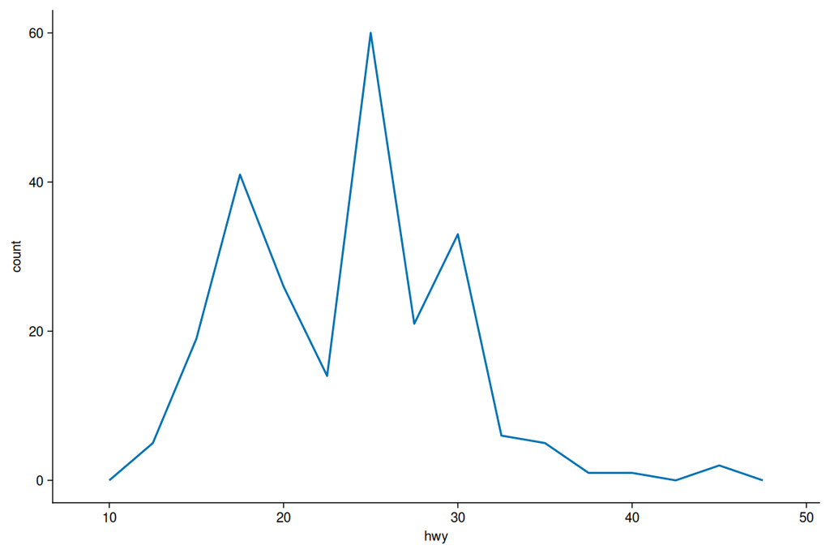

## Freqpoly by group — ggplot2

```r
ggplot(mpg, aes(displ, colour = drv)) +
  geom_freqpoly(binwidth = 0.5)
```

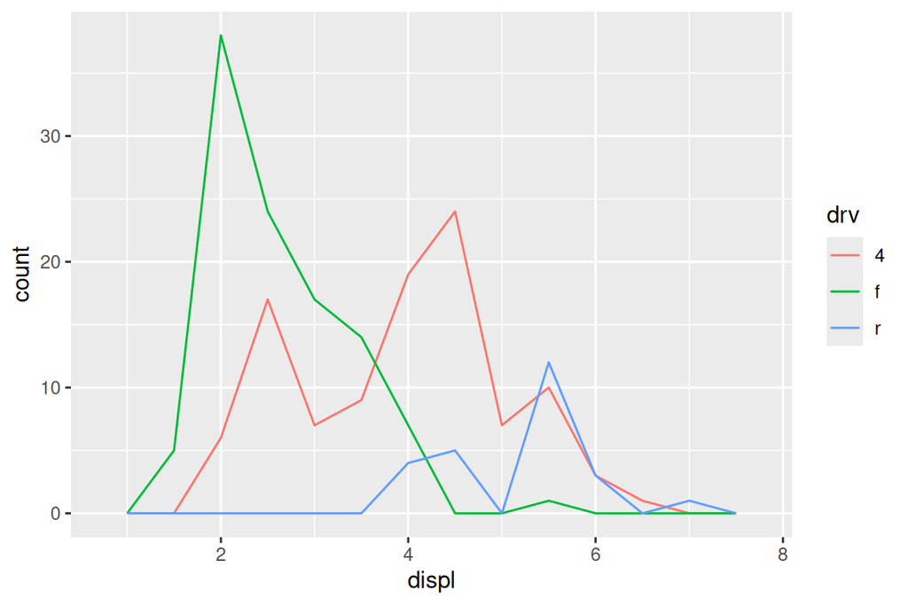

## Freqpoly by group — tidyplots

```r
mpg |>
  tidyplot(x = displ, color = drv, width = NA, height = NA) |>
  add(ggplot2::geom_freqpoly(binwidth = 0.5))
```

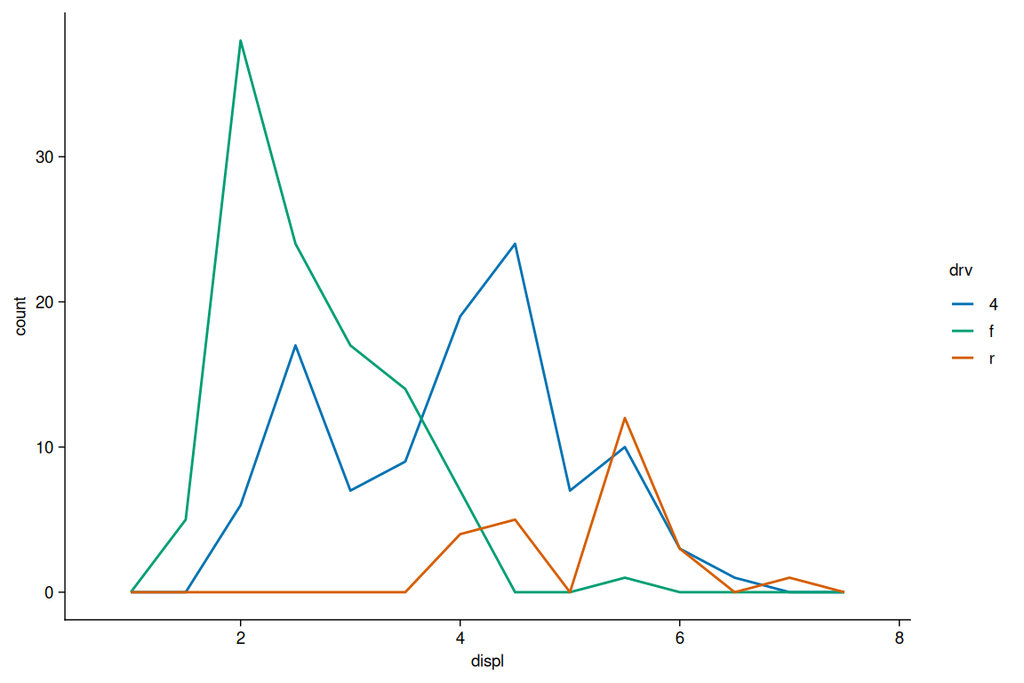

## Histogram faceted by group — ggplot2

```r
ggplot(mpg, aes(displ, fill = drv)) +
  geom_histogram(binwidth = 0.5) +
  facet_wrap(~ drv, ncol = 1)
```

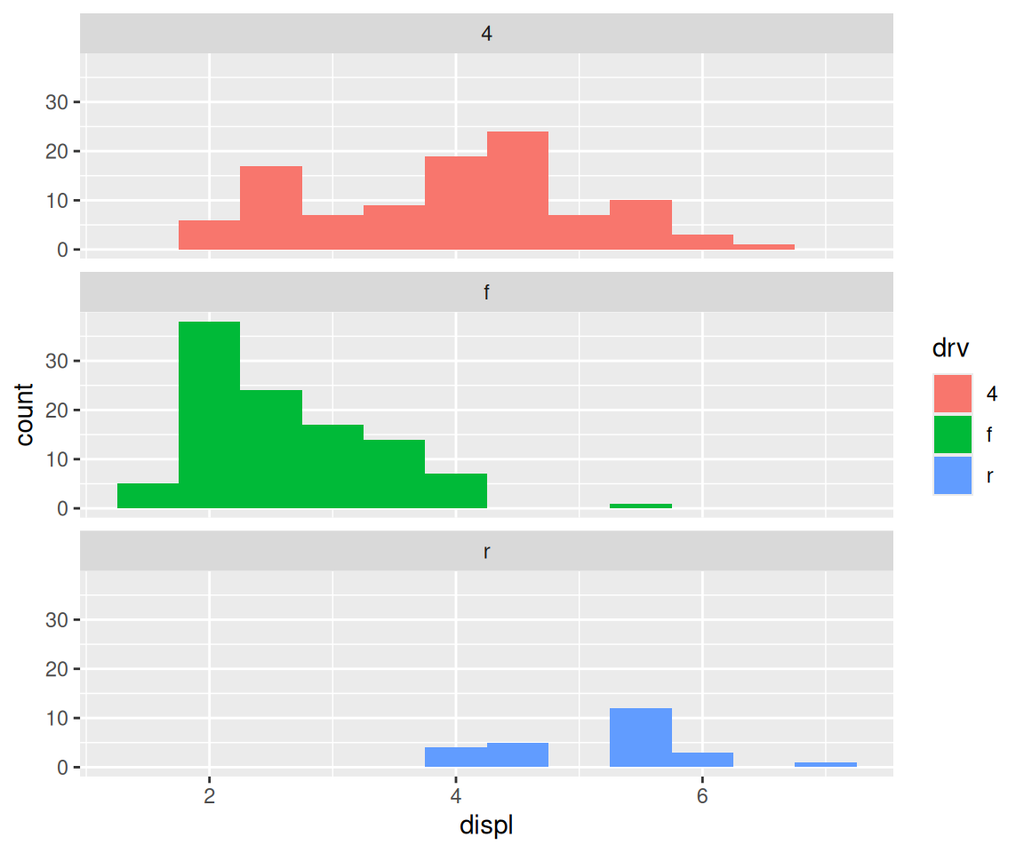

## Histogram faceted by group — tidyplots

```r
mpg |>
  tidyplot(x = displ, color = drv, width = NA, height = NA) |>
  add_histogram(binwidth = 0.5) |>
  add(ggplot2::facet_wrap(~ drv, ncol = 1))
```

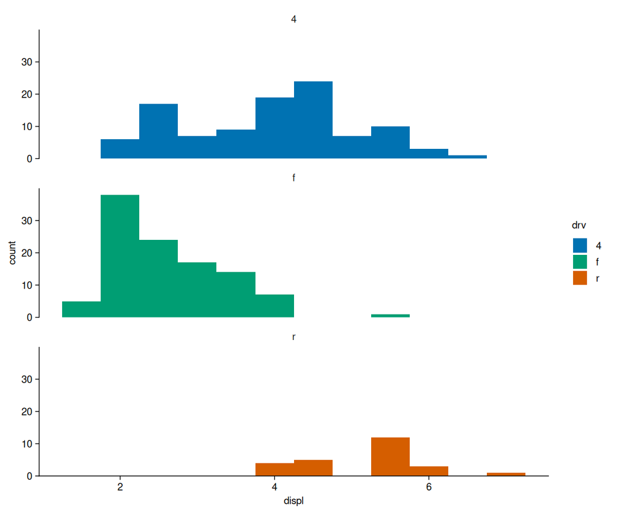

## Bar chart (counts) — ggplot2

```r
ggplot(mpg, aes(manufacturer)) + geom_bar()
```

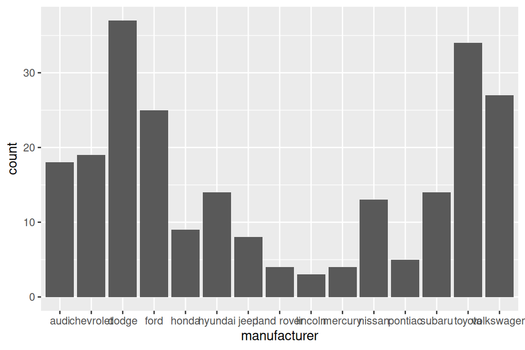

## Bar chart (counts) — tidyplots

```r
mpg |>
  tidyplot(x = manufacturer, width = NA, height = NA) |>
  add_count_bar()
```

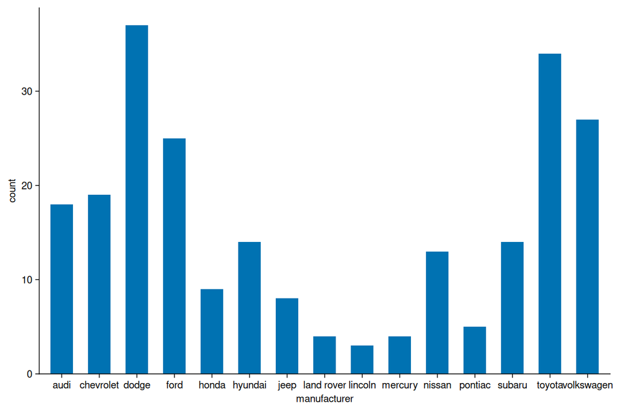

## Bar chart (identity) — ggplot2

```r
drugs <- data.frame(drug = c("a", "b", "c"), effect = c(4.2, 9.7, 6.1))
ggplot(drugs, aes(drug, effect)) + geom_bar(stat = "identity")
```

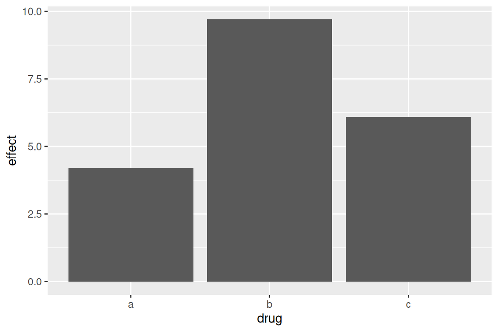

## Bar chart (identity) — tidyplots

```r
drugs <- data.frame(drug = c("a", "b", "c"), effect = c(4.2, 9.7, 6.1))
drugs |>
  tidyplot(x = drug, y = effect, width = NA, height = NA) |>
  add_sum_bar()
```

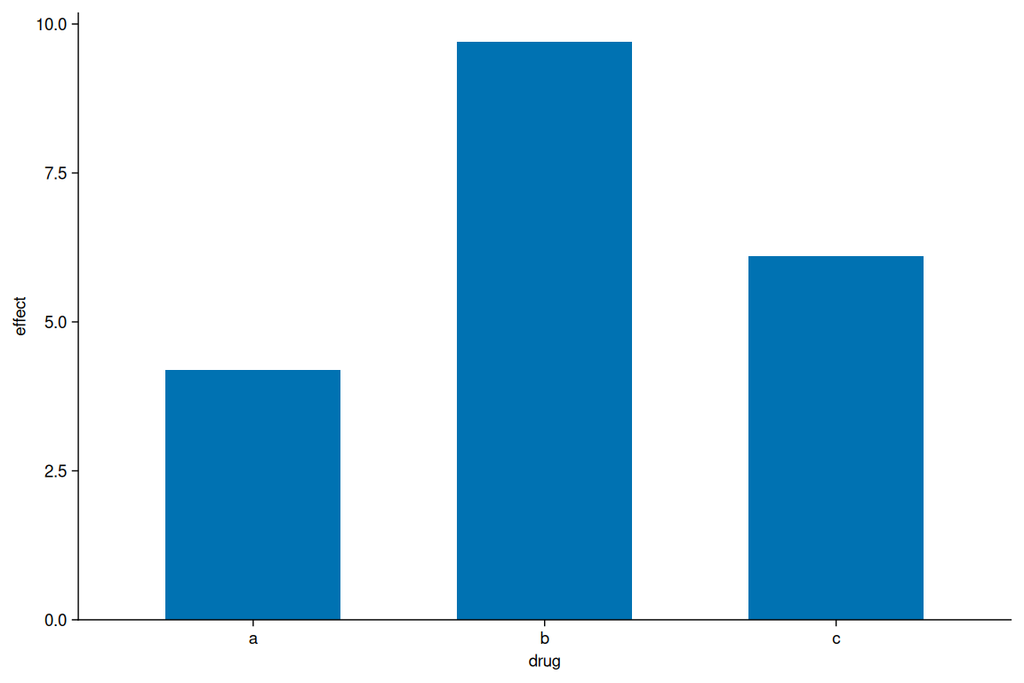

## Line plot — ggplot2

ggplot2 computes the y ratio inside `aes()`.

```r
ggplot(economics, aes(date, unemploy / pop)) +
  geom_line()
```

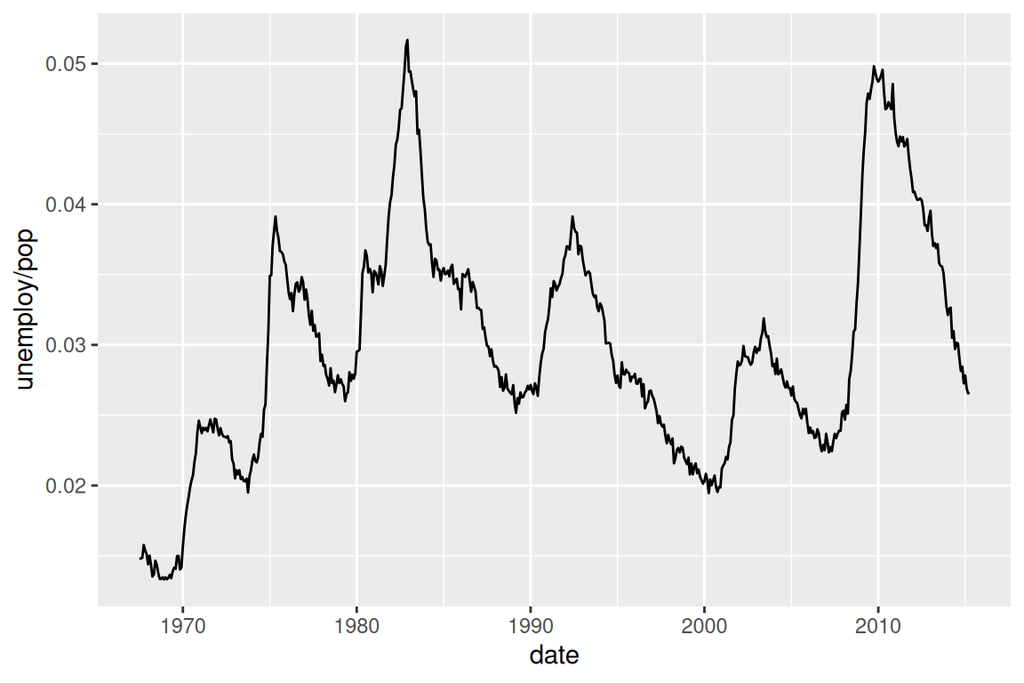

## Line plot — tidyplots

tidyplots needs a real column, so we `mutate()` it first.

```r
economics |>
  mutate(unemploy_rate = unemploy / pop) |>
  tidyplot(x = date, y = unemploy_rate, width = NA, height = NA) |>
  add_line()
```

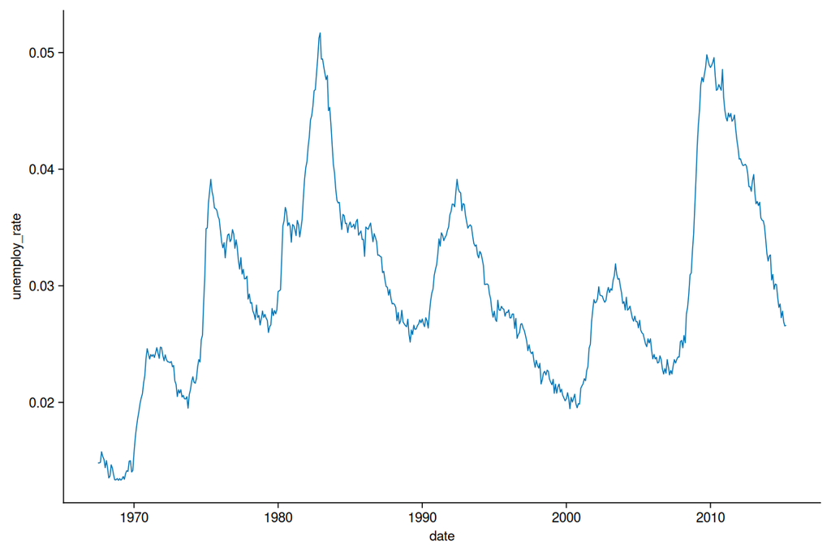

## Path coloured by year — ggplot2

```r
year <- function(x) as.POSIXlt(x)$year + 1900
ggplot(economics, aes(unemploy / pop, uempmed)) +
  geom_path(colour = "grey50") +
  geom_point(aes(colour = year(date)))
```

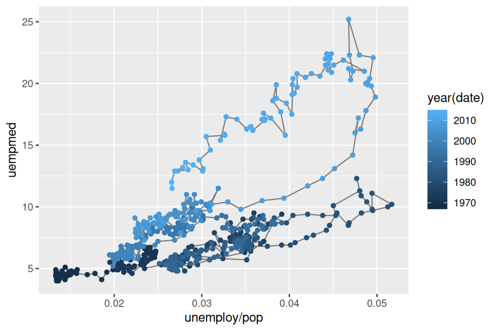

## Path coloured by year — tidyplots

Both transformed columns precomputed; the path goes in via the escape hatch.

```r
economics |>
  mutate(unemploy_rate = unemploy / pop,
         year = as.POSIXlt(date)$year + 1900) |>
  tidyplot(x = unemploy_rate, y = uempmed, color = year,
           width = NA, height = NA) |>
  add(ggplot2::geom_path(ggplot2::aes(color = NULL), colour = "grey50")) |>
  add_data_points()
```

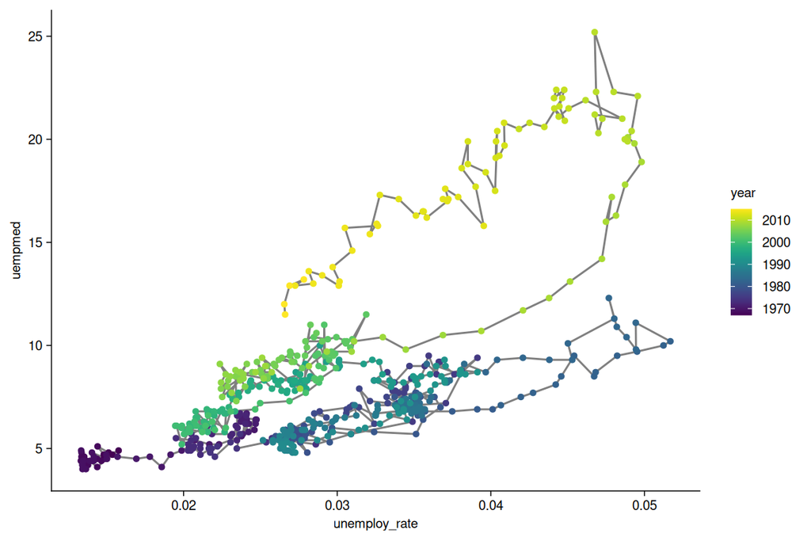

## Adding axis titles — ggplot2

```r
ggplot(mpg, aes(cty, hwy)) +
  geom_point(alpha = 1 / 3) +
  xlab("city driving (mpg)") +
  ylab("highway driving (mpg)")
```

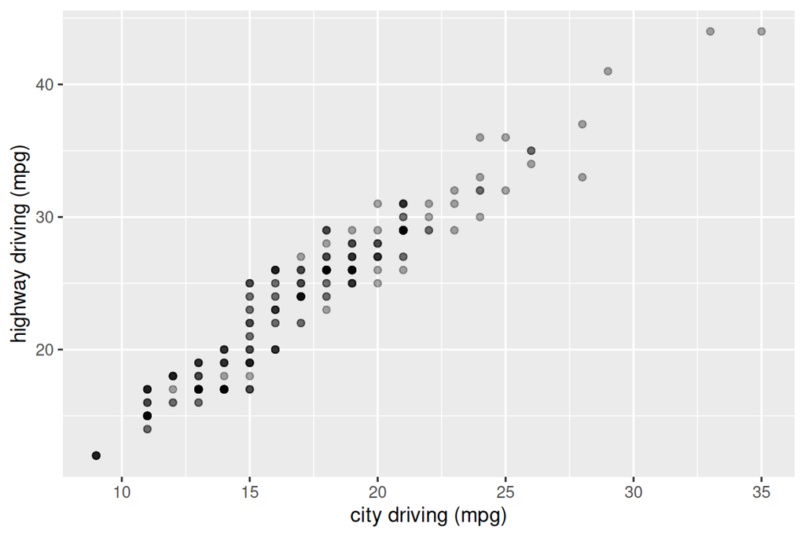

## Adding axis titles — tidyplots

```r
mpg |>
  tidyplot(x = cty, y = hwy, width = NA, height = NA) |>
  add_data_points(alpha = 1 / 3) |>
  adjust_x_axis_title("city driving (mpg)") |>
  adjust_y_axis_title("highway driving (mpg)")
```

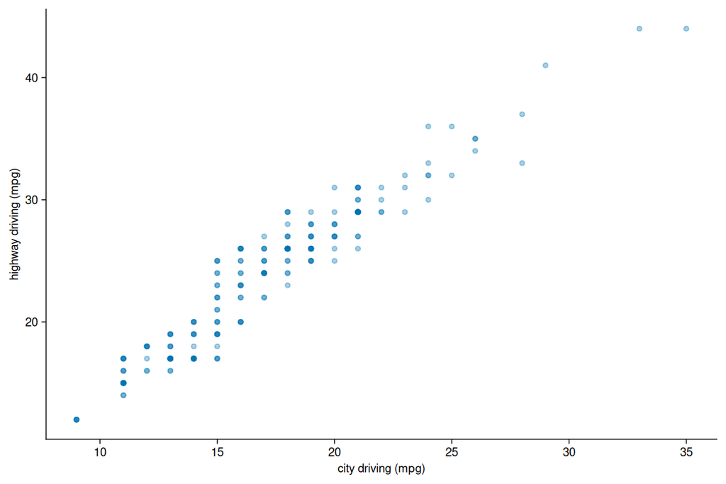

## Removing titles — ggplot2

```r
ggplot(mpg, aes(cty, hwy)) +
  geom_point(alpha = 1 / 3) +
  xlab(NULL) + ylab(NULL)
```

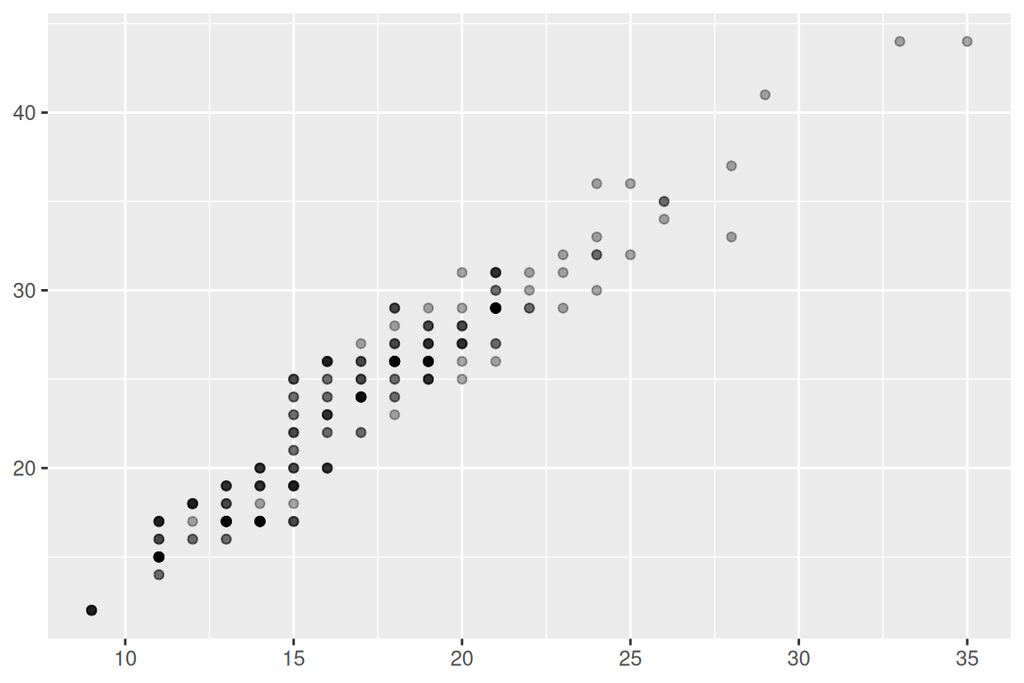

## Removing titles — tidyplots

```r
mpg |>
  tidyplot(x = cty, y = hwy, width = NA, height = NA) |>
  add_data_points(alpha = 1 / 3) |>
  remove_x_axis_title() |>
  remove_y_axis_title()
```

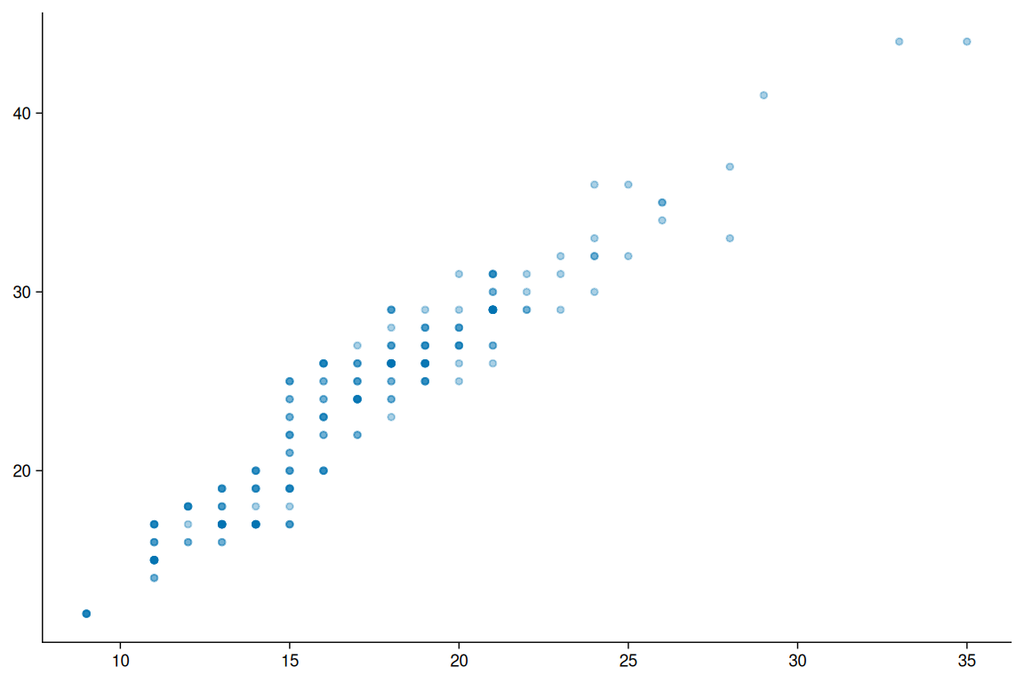

## Axis limits — ggplot2

```r
ggplot(mpg, aes(drv, hwy)) +
  geom_jitter(width = 0.25) +
  xlim("f", "r") +
  ylim(20, 30)
```

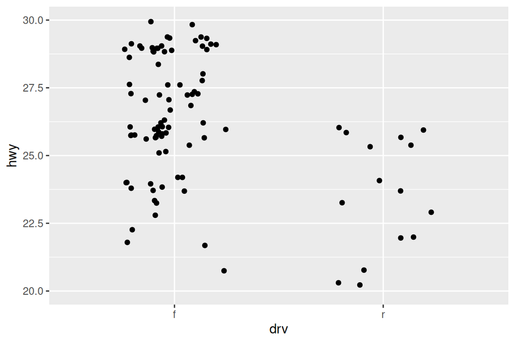

## Axis limits — tidyplots

No category-picking limit, so we filter the data instead.

```r
mpg |>
  dplyr::filter(drv %in% c("f", "r")) |>
  tidyplot(x = drv, y = hwy, width = NA, height = NA) |>
  add_data_points_jitter() |>
  adjust_y_axis(limits = c(20, 30))
```

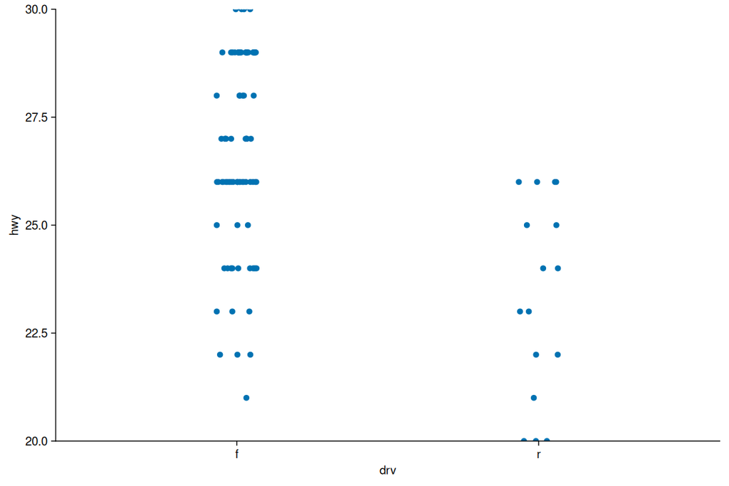

## Saving the plot

Both return an object you can store, print, and save. tidyplots returns a ggplot under the hood, so `ggsave()` still works, but tidyplots also ships its own `save_plot()` (note the argument order: the plot comes first).

```r
p <- mpg |>
  mutate(cyl_f = factor(cyl)) |>
  tidyplot(x = displ, y = hwy, color = cyl_f, width = NA, height = NA) |>
  add_data_points()

p                                                                 # print it
save_plot(p, "plot.png", width = 10, height = 10, units = "cm")   # tidyplots
ggplot2::ggsave("plot.png", p, width = 5, height = 5)             # also works
```

## Arranging plots: `patchwork`

- Arranging finished plots into one figure is **not** part of ggplot2 or tidyplots. It is the job of [patchwork](https://patchwork.data-imaginist.com).
- A `tidyplot()` returns a ggplot under the hood, so `+`, `/`, `|`, `plot_layout()`, `plot_annotation()`, and `inset_element()` work on tidyplots **unchanged**.
- tidyplots’ own multi-panel verb `split_plot()` is faceting (one plot, many panels), not composition. For composition, reach for patchwork.
- Always build tidyplots panels with `width = NA, height = NA`, otherwise every panel is locked to a fixed 50 x 50 mm square and patchwork can’t align them.

## Patchwork setup

```r
library(patchwork)
```

## Four base plots — ggplot2 (code)

```r
p1 <- ggplot(mpg) +
  geom_point(aes(x = displ, y = hwy))

p2 <- ggplot(mpg) +
  geom_bar(aes(x = as.character(year), fill = drv), position = "dodge") +
  labs(x = "year")

p3 <- ggplot(mpg) +
  geom_density(aes(x = hwy, fill = drv), colour = NA) +
  facet_grid(rows = vars(drv))

p4 <- ggplot(mpg) +
  stat_summary(aes(x = drv, y = hwy, fill = drv),
               geom = "col", fun.data = mean_se) +
  stat_summary(aes(x = drv, y = hwy),
               geom = "errorbar", fun.data = mean_se, width = 0.5)
```

## Four base plots — ggplot2 (2x2)

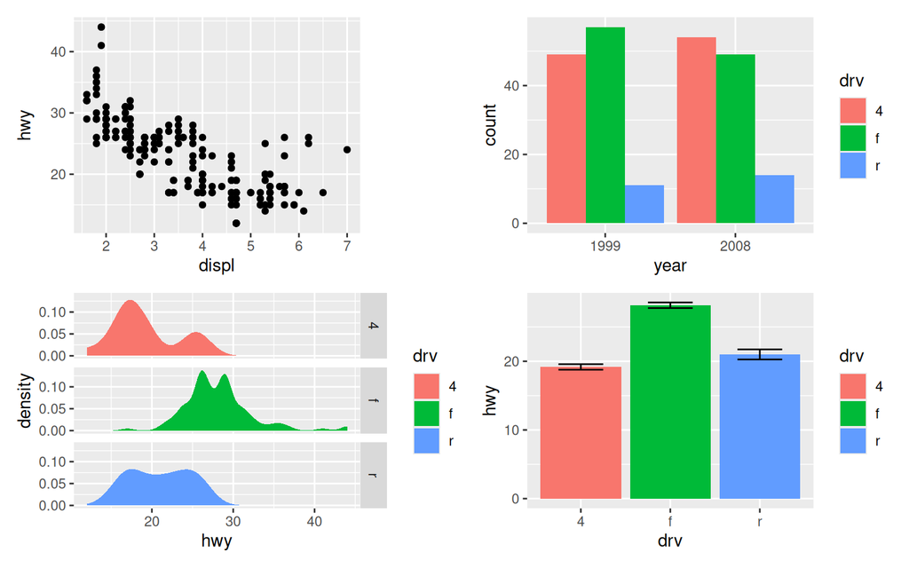

## Four base plots — tidyplots (code)

`add_count_bar()` replaces dodged `geom_bar()`; `add_mean_bar()` + `add_sem_errorbar()` replace the two `stat_summary()` layers. The filled density has no native verb, so use the escape hatch.

```r
mpg2 <- mpg |> mutate(year_chr = as.character(year))

t1 <- mpg |> tidyplot(x = displ, y = hwy, width = NA, height = NA) |>
  add_data_points()

t2 <- mpg2 |> tidyplot(x = year_chr, color = drv, width = NA, height = NA) |>
  add_count_bar()

t3 <- mpg |> tidyplot(x = hwy, color = drv, width = NA, height = NA) |>
  add(ggplot2::geom_density(ggplot2::aes(fill = drv), colour = NA)) |>
  add(ggplot2::facet_grid(rows = vars(drv)))

t4 <- mpg |> tidyplot(x = drv, y = hwy, color = drv, width = NA, height = NA) |>
  add_mean_bar() |>
  add_sem_errorbar()
```

## Four base plots — tidyplots (2x2)

The composition line `t1 + t2 + t3 + t4` is byte-for-byte the same as `p1 + p2 + p3 + p4`.

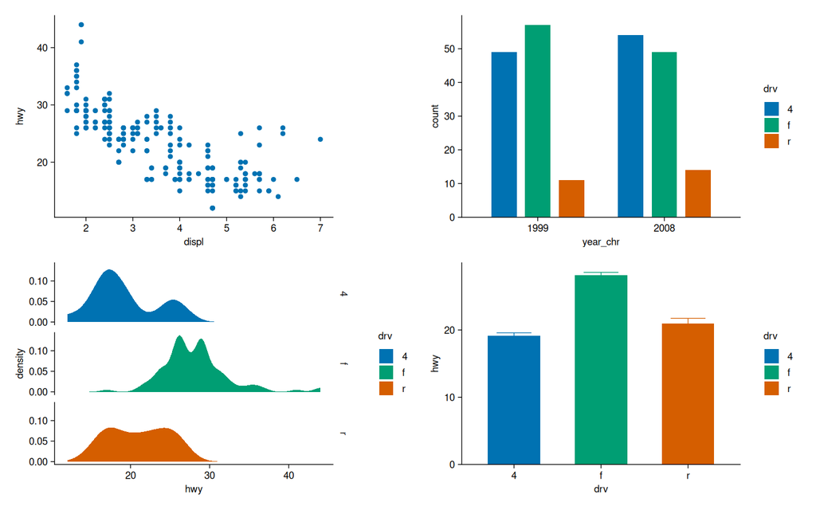

## Side by side — ggplot2

`+` places plots next to each other.

```r
p1 + p2
```

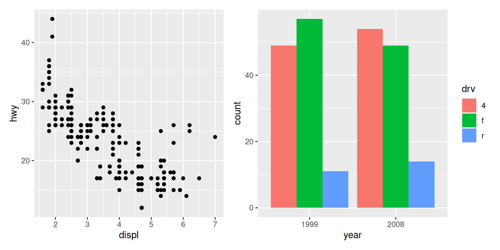

## Side by side — tidyplots

Identical patchwork code.

```r
t1 + t2
```

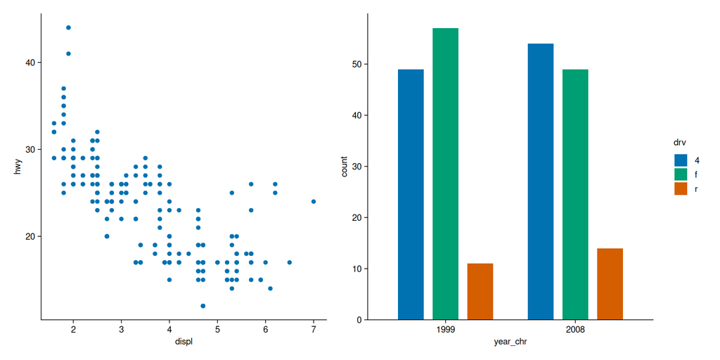

## Free-form layout (`design = ...`) — ggplot2

```r
layout <- "
AAB
C#B
CDD
"
p1 + p2 + p3 + p4 + plot_layout(design = layout)
```

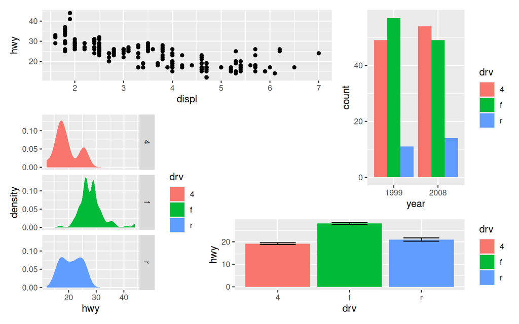

## Free-form layout (`design = ...`) — tidyplots

```r
t1 + t2 + t3 + t4 + plot_layout(design = layout)
```

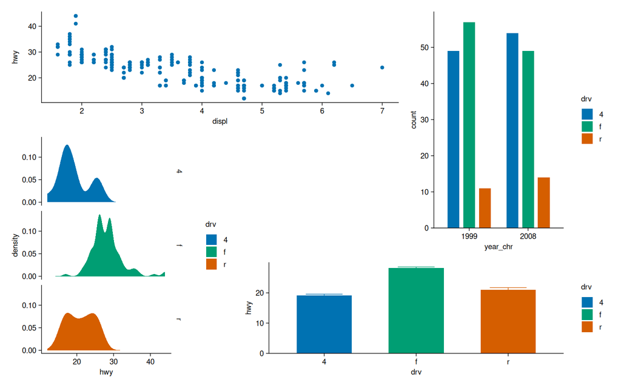

## Collecting guides — ggplot2

`guides = "collect"` pulls duplicate legends out into one shared legend.

```r
p2 + p4 + plot_layout(ncol = 2, guides = "collect")
```

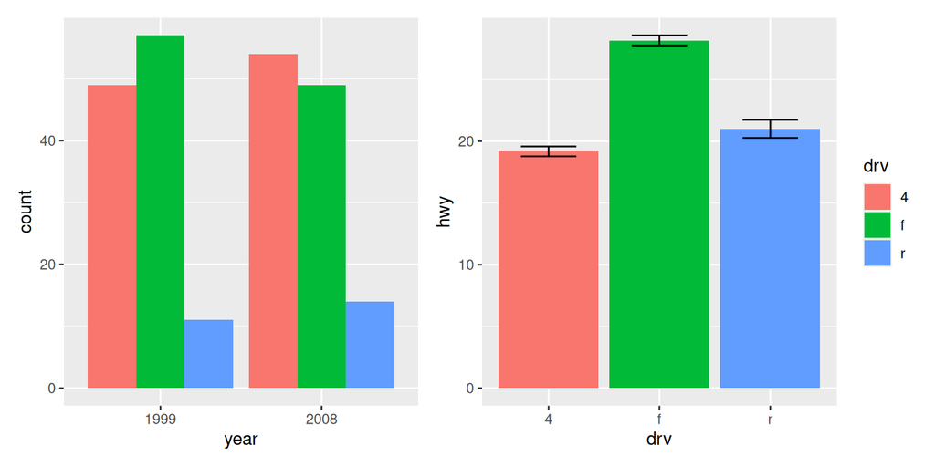

## Collecting guides — tidyplots

```r
t2 + t4 + plot_layout(ncol = 2, guides = "collect")
```

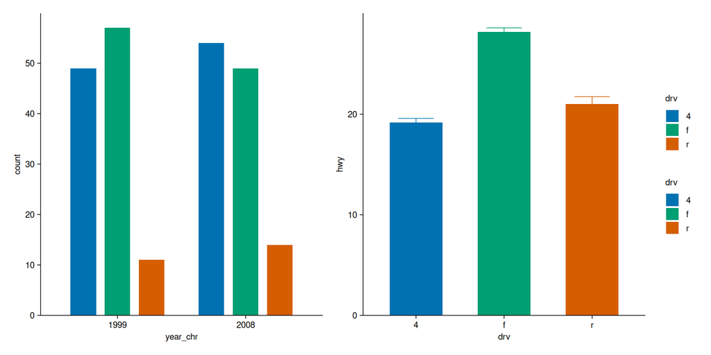

## Apply to all panels with `&` — ggplot2

`&` adds a component to every panel.

```r
p1 + p4 & scale_y_continuous(limits = c(0, 45))
```

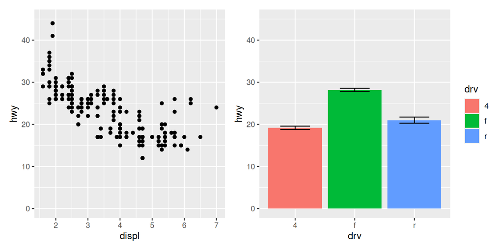

## Apply to all panels with `&` — tidyplots

```r
t1 + t4 & scale_y_continuous(limits = c(0, 45))
```

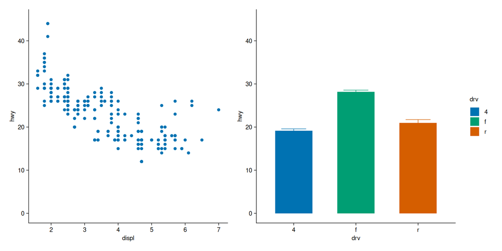

## tidyplots gotcha: `&` with a theme overwrites tidyplots’ styling

- `&` applies the component to every panel.
- Adding a whole ggplot2 theme such as `theme_minimal()` **replaces** the tidyplots default styling on every panel.
- Use narrower components (a scale, a coord) with `&` if you want to keep the tidyplots look.

## Title, caption, auto-tags — ggplot2

```r
(p1 | (p2 / p3)) + plot_annotation(
  title    = "A closer look at the effect of drive train in cars",
  caption  = "Source: mpg dataset in ggplot2",
  tag_levels = "I"
)
```

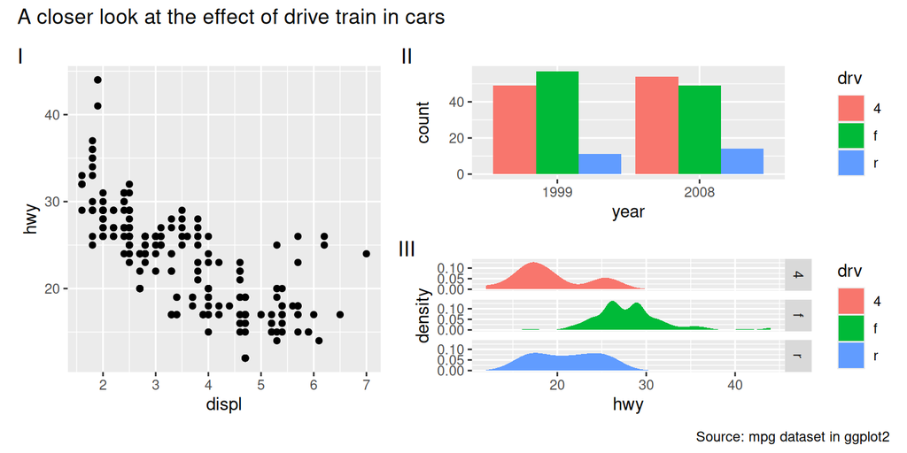

## Title, caption, auto-tags — tidyplots

```r
(t1 | (t2 / t3)) + plot_annotation(
  title    = "A closer look at the effect of drive train in cars",
  caption  = "Source: mpg dataset in ggplot2",
  tag_levels = "I"
)
```

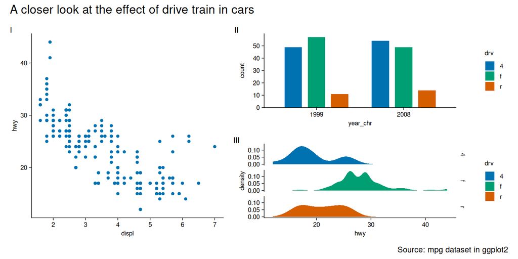

## Insets with `inset_element()` — ggplot2

```r
p1 + inset_element(p2, left = 0.5, bottom = 0.45, right = 0.95, top = 0.95)
```

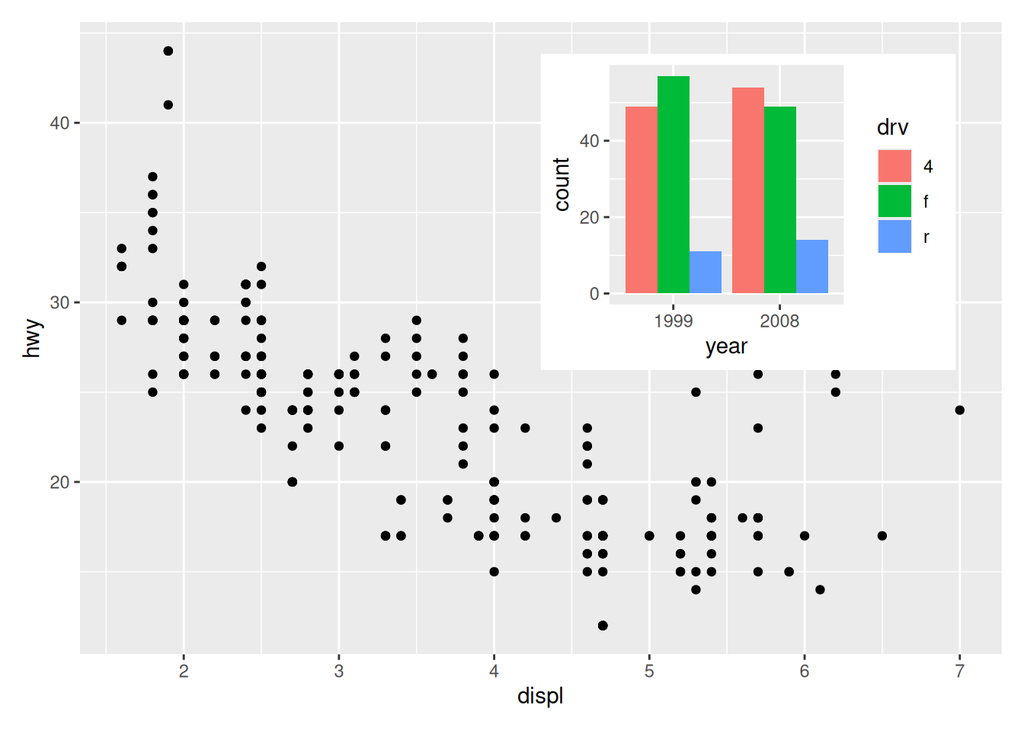

## Insets with `inset_element()` — tidyplots

```r
t1 + inset_element(t2, left = 0.5, bottom = 0.45, right = 0.95, top = 0.95)
```

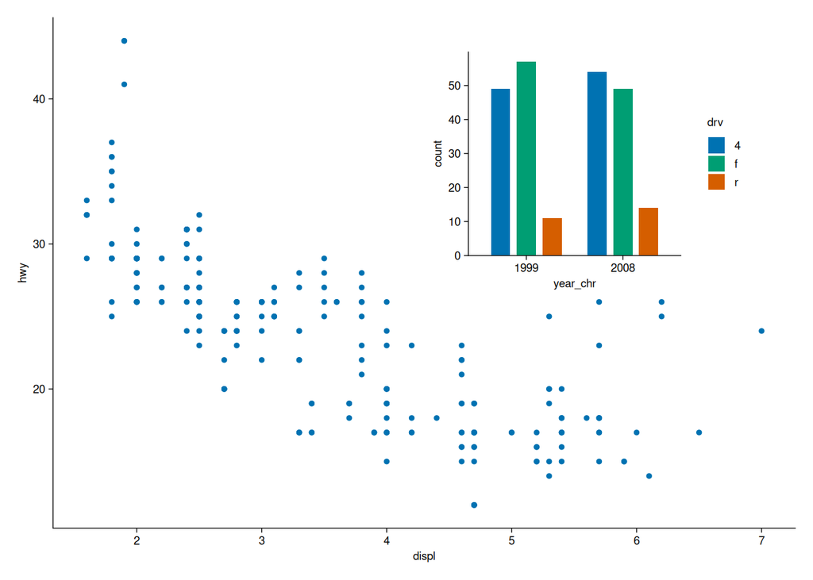

## `split_plot()` is not patchwork

- `split_plot(by = v)` takes **one** plot and one variable, makes one panel per level. That is faceting.
- patchwork (`+`, `/`, `|`, `inset_element()`) takes several **already-built**, unrelated plots and arranges them. That is composition.

```r
mpg |>
  tidyplot(x = displ, y = hwy, width = NA, height = NA) |>
  add_data_points() |>
  split_plot(by = drv)
```

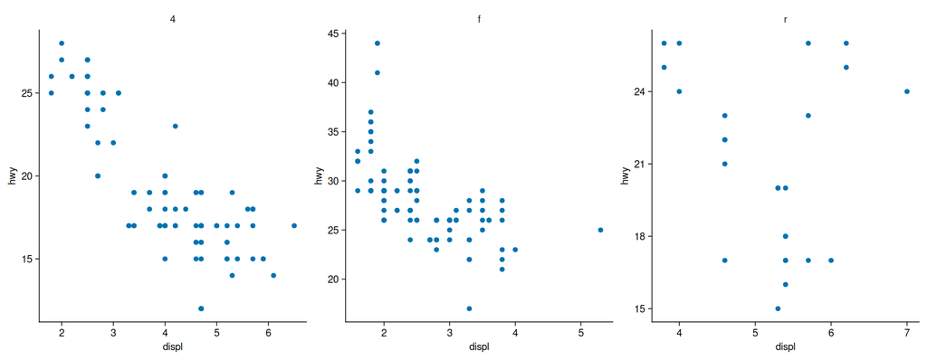

## Patchwork exercise

Take 2 `ggplot2` plots and 2 `tidyplots` plots (e.g. from above or from another)

## Takeaways

- For the everyday plots in this chapter, tidyplots has a one-to-one verb: `add_data_points()`, `add_curve_fit()`, `add_boxplot()`, `add_violin()`, `add_histogram()`, `add_count_bar()`, `add_line()`.
- The grammar difference is where the mapping lives: inside `aes()` for ggplot2, inside `tidyplot()` for tidyplots, with grouping always carried by `color`.
- tidyplots will not evaluate transformed expressions in a mapping, so precompute with `mutate()`.
- It has no verb for a handful of geoms like `geom_freqpoly()` and `geom_path()`, so reach for the escape hatch `add(ggplot2::...)`.
- `split_plot()` is tidyplots’ faceting verb, but it free-scales each panel. Use `add(ggplot2::facet_wrap(...))` when you need ggplot2’s shared scales.

# More issues in tidyplots compared to ggplot2

## The fixed-panel-size trap

- tidyplots’ `tidyplot()` defaults to a **fixed 50 x 50 mm** panel.
- That square 1:1 panel fights the chunk’s `fig-width`/`fig-height`, makes single plots square, and clips axes off faceted figures.
- **Default rule:** always pass `width = NA, height = NA` to `tidyplot()`, so each panel flexes like a ggplot2 panel.
- Inflating `fig-width`/`fig-height` only papers over the symptom; the real fix is `width = NA, height = NA`.

## Faceting: `split_plot()` free-scales each panel

- `facet_wrap()` shares x and y scales across panels. `split_plot()` builds each panel **independently** and free-scales it.
- `split_plot(scales = "fixed")` only synchronises x, the measure axis still varies.
- For ggplot2’s shared scales, use the escape hatch: `add(ggplot2::facet_wrap(~ class))` together with `width = NA, height = NA`.

## `facet_grid` through the escape hatch loses axes

- tidyplots’ minimal theme does **not** render `facet_grid` panels, panel borders, ticks, and tick text come out blank.
- Re-apply a full ggplot2 theme **after** the facet to restore them:

```r
tp |>
  add(ggplot2::facet_grid(cyl ~ class)) |>
  add(ggplot2::theme_bw())
```

- `split_plot(rows = cyl, cols = class)` keeps axes but draws **no row/column strip labels**, so you can’t tell which row is which. Prefer `facet_grid` + `theme_bw()`.

## Global `color` groups every statistical layer

- `tidyplot(..., color = state)` is **global**, every downstream layer inherits the grouping, including `add_curve_fit()`.
- That fits one curve **per state**. ggplot2 only groups layers whose own `aes()` carries the mapping.
- To get a single global fit while points stay coloured by state: escape-hatch `geom_smooth(aes(color = NULL, group = 1), ...)`.
- To get one fit per group, just `add_curve_fit(method = "lm")` with no overrides.

## `xlim` / `ylim` vs `adjust_*_axis(limits=)`

- ggplot2’s `xlim()`/`ylim()` **drop** points outside the range before any stat runs, so `geom_smooth()` refits on what remains.
- tidyplots’ `adjust_x_axis(limits=)` / `adjust_y_axis(limits=)` keep all points and only **zoom**, so a curve fit still sees out-of-range points and can take a different shape.
- To match ggplot2’s clipping behaviour, **pre-filter** the data.
- `coord_cartesian()` (zoom, keep points) maps to `add(ggplot2::coord_cartesian())` and needs no pre-filter.

## Other small but real divergences

- `add_curve_fit()` draws a **ribbon by default**. Match `geom_smooth(se = FALSE)` with `add_curve_fit(se = FALSE)`.
- `tidyplot()` **rejects transformed expressions** in mappings (`y = unemploy / pop`, `colour = factor(cyl)`). Precompute with `mutate()`.
- Stripping a plot: tidyplots draws **`axis.line` elements**, not a panel border. `remove_x_axis_*()`/`remove_y_axis_*()` drop only ticks, labels, and titles. To fully strip, also blank `axis.line` via `adjust_theme_details()`.

## More small but real divergences

- `scale_x_reverse()` **replaces** an existing x scale, so any earlier `xlim()` is discarded. Put limits on the reverse scale itself, high-to-low: `scale_x_reverse(limits = c(0.1, 0))`.

## Workflow notes

- Verify verb names against the **installed** tidyplots before writing a handout: `ls("package:tidyplots")` then grep `^add_`, `^adjust_`, `^remove_`. The API drifts between releases.
- Smoke-test every translated chunk with `ggplot2::ggplot_build(<tidyplot>)` in a batch script before rendering, so API drift surfaces fast.

## Exercise

Take 2 plots from https://jbengler.github.io/tidyplots/ and rewrite them as `ggplot2` plots. The `ggplot2` cheatsheet https://opensource.posit.co/resources/cheatsheets/data-visualization/data-visualization.pdf can help, as can an LLM coding assistant. Why is the `tidyplot` cheatsheet https://tidyplots.org/tidyplots-cheatsheet-v1.pdf half the size of the `ggplot2` cheatsheet?

# Bonus material on low-level graphics

## tidyplots → ggplot2 → grid

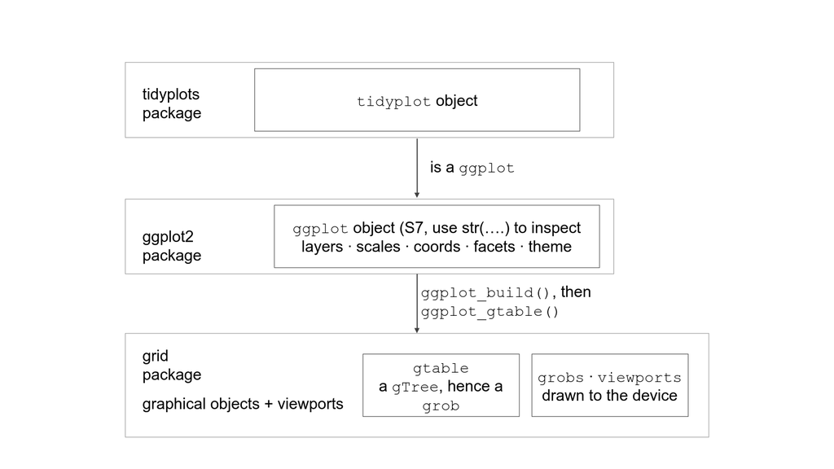

## grid: the engine under ggplot2

ggplot2, tidyplots, and patchwork all draw through the **grid** graphics system that ships with base R. Knowing a little grid lets you reach under the hood when the high-level grammars run out.

| Concept | Role |
| --- | --- |
| **device** | the physical page (file/window) |
| **viewport** | a coordinate region on the page |
| **grob** | a drawable thing (rect, text, points, gtable) |
| **gtable** | a grob that *arranges other grobs* by pushing viewports |

The chain: a gtable defines a layout, pushes viewports, draws grobs into them, onto the device.

## Viewports and grobs: a tiny example (code)

```r
library(grid)
grid.newpage()

# a viewport is a coordinate region; name it so we can re-enter it
pushViewport(viewport(x = 0.5, y = 0.5, width = 0.6, height = 0.6,
                      name = "inner"))
grid.rect(gp = gpar(lty = "dashed"))         # outlines THIS viewport
grid.text("inner viewport: x, y run 0..1 here", y = 0.92)
grid.points(runif(20), runif(20), pch = 19,  # placed in viewport coords
            gp = gpar(col = "steelblue"))
upViewport()                                  # back to the root viewport

# re-enter the named viewport later and annotate in its coordinates
downViewport("inner")
grid.points(0.5, 0.5, pch = 4,
            gp = gpar(col = "red", cex = 3, lwd = 3))
upViewport()
```

## Viewports and grobs: a tiny example (plot)

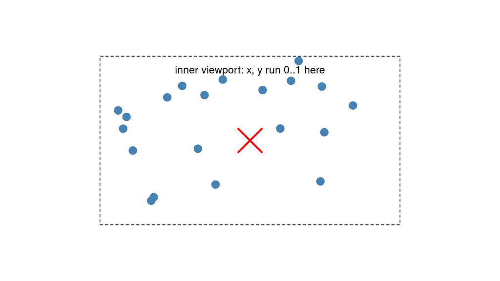

## Why it matters for ggplot2/tidyplots

- Every ggplot2 panel, strip, axis, legend, and patchwork composition is a **gtable** of grobs in viewports. `ggplotGrob(p)` returns it.
- That is how patchwork can align panels: it inspects and recombines the underlying gtables.
- `gridExtra::grid.arrange()` is a thin patchwork-like wrapper over the same machinery.
- When a high-level fix isn’t enough (custom annotation in figure coordinates, a logo in a margin, hand-tweaking a strip), you drop down to grid.

## References

- Wickham H, Navarro D, Pedersen TL. *ggplot2: Elegant Graphics for Data Analysis* (3rd edition). The source for most of the example (dtrafts of chapters *First steps* and *Arranging plots*). https://ggplot2-book.org/getting-started.html, https://ggplot2-book.org/arranging-plots.html
- Engler JB (2025). “Tidyplots empowers life scientists with easy code-based data visualization.” *iMeta*, e70018. [doi:10.1002/imt2.70018](https://doi.org/10.1002/imt2.70018)
- Wood SN (2011). “Fast stable restricted maximum likelihood and marginal likelihood estimation of semiparametric generalized linear models.” *JRSS (B)* 73(1):3-36. [doi:10.1111/j.1467-9868.2010.00749.x](https://doi.org/10.1111/j.1467-9868.2010.00749.x)
- Murrell P (2018). *R Graphics* (3rd edition). CRC Press. The canonical reference for grid, viewports, and grobs. https://www.stat.auckland.ac.nz/~paul/RG3e/
- Murrell P (2012). “grid Graphics.” Chapter in the R distribution. https://stat.ethz.ch/R-manual/R-devel/library/grid/doc/grid.pdf
- Auguie B. *gridExtra: Miscellaneous Functions for “Grid” Graphics*. https://cran.r-project.org/package=gridExtra
- Wickham H. *gtable: Arrange “Grobs” in Tables*. https://cran.r-project.org/package=gtable

# Coda: do we still need to write the code?

## We don’t write this anymore

**What we wrote in 1993 (C)**

```c
int count_kmer(const char *seq,
               const char *kmer) {
  int n = 0,
      k = strlen(kmer),
      L = strlen(seq);
  for (int i = 0; i <= L - k; i++)
    if (!strncmp(seq + i, kmer, k))
      n++;
  return n;
}
```

**What the CPU runs (x86-64 assembly)**

```
count_kmer:
    endbr64
    push    r14
    push    r13
    mov     r13, rsi
    push    r12
    push    rbp
    push    rbx
    mov     rbx, rdi
    mov     rdi, rsi
    call    strlen@PLT
    mov     rdi, rbx
    mov     r12, rax
    call    strlen@PLT
    sub     eax, r12d
    js      .L5
    cdqe
    movsx   r12, r12d
    xor     ebp, ebp
    lea     r14, 1[rbx+rax]
.L4:
    mov     rdi, rbx
    mov     rdx, r12
    mov     rsi, r13
    call    strncmp@PLT
    cmp     eax, 1
    adc     ebp, 0
    add     rbx, 1
    cmp     rbx, r14
    jne     .L4
    ret
```

A few lines of C on the left, the x86-64 assembly the CPU actually runs on the right. The compiler does the translation, nobody hand-writes the right-hand side.

## Another `count_kmer` now

One R function call from **stringr**.

```r
library(stringr)
str_count("ACGTACGTACGT", "ACG")
```

```
#> [1] 3
```

and python

```python
"ACGTACGTACGT".count("ACG")
# 3
```

No imports, no loop, no pointer arithmetic.

## A subtle catch: overlapping matches

- The C version above slides one base at a time, so it **counts overlapping k-mers**: `count_kmer("AAAA", "AA")` returns **3** (positions 0, 1, 2).
- `stringr::str_count()` and Python’s `str.count()` are **non-overlapping**: both return **2** for `"AAAA"` vs `"AA"` (positions 0, 2).
- The default the language gives you is often not the default biology wants.

## Counting overlapping k-mers

To match the C version’s signature, wrap the trick in a function of `(seq, kmer)`. A lookahead regex `(?=...)` matches a **position**, not characters, so positions can overlap.

**R**:

```r
count_kmer <- function(seq, kmer) {
  str_count(seq, paste0("(?=", kmer, ")"))
}
count_kmer("AAAA", "AA")
```

```
#> [1] 3
```

**Python**:

```python
import re
def count_kmer(seq, kmer):
    return len(re.findall(f"(?={kmer})", seq))

count_kmer("AAAA", "AA")
# 3
```

## Lookahead / lookbehind: what they are

A **lookaround** is a *zero-width assertion*. It checks whether a pattern matches at the current cursor position, but consumes **no characters**, so the cursor only advances by the engine’s normal one step.

| Syntax | Name | Meaning |
| --- | --- | --- |
| `(?=X)` | positive lookahead | next chars **do** match `X` |
| `(?!X)` | negative lookahead | next chars **do not** match `X` |
| `(?<=X)` | positive lookbehind | previous chars **do** match `X` |
| `(?<!X)` | negative lookbehind | previous chars **do not** match `X` |

Other zero-width things you’ve already seen: `^`, `$`, `\b` (word boundary). They all assert a *position*, not characters.

## Lookaround: why overlap works, and other uses

Walking `"AAAA"` with `(?=AA)`: position 0 sees `AA` (match, cursor -> 1), position 1 sees `AA` (match, cursor -> 2), position 2 sees `AA` (match, cursor -> 3), position 3 sees only `A` (no match). **Three matches**, because the cursor advances by 1 each time instead of 2.

Other handy uses:

- `\d+(?=bp)` matches a number only if followed by `bp`, but `bp` is not in the match.
- `ACG(?!T)` matches `ACG` only when it is **not** followed by `T`.
- `(?<=chr)\d+` matches the digits after `chr` without including `chr` in the match.

## Overlapping k-mers with `N` wildcard and case-insensitive

**R** (`stringr` uses ICU regex, so lookahead + `ignore_case` both work):

```r
library(stringr)
count_overlap_kmer <- function(seq, kmer) {
  bases <- strsplit(kmer, "")[[1]]
  pat   <- paste0("(?=", paste0("[", bases, "N]", collapse = ""), ")")
  str_count(seq, regex(pat, ignore_case = TRUE))
}
count_overlap_kmer("acgNacGtNcg", "ACG")
```

[output not shown]

**Python**:

```python
import re
def count_overlap_kmer(seq, kmer):
    pat = "(?=" + "".join(f"[{b}N]" for b in kmer) + ")"
    return len(re.findall(pat, seq, flags=re.IGNORECASE))

count_overlap_kmer("acgNacGtNcg", "ACG")
# 3
```

The trick: for each base `b` in the query, allow `[bN]` in the sequence; wrap the whole thing in `(?=...)` for overlap; turn on case-insensitive matching.

## Or just use Bioconductor: `Biostrings`

The bioinformatics-native answer. Overlap, IUPAC, and mismatches are already built in.

```r
library(Biostrings)
seq <- DNAString("ACGNCGTANG")

# overlapping by default; N in the subject matches any base
countPattern("ACG", seq,
             fixed = c(pattern = TRUE, subject = FALSE))
```

```
#> [1] 3
```

```r
# the full k-mer spectrum in one call
oligonucleotideFrequency(seq, width = 3)
```

```
#> AAA AAC ... ACG ... TTT
```

| Function | Best for |
| --- | --- |
| `stringr::str_count` + `(?=)` | One-off on a plain character string, any alphabet |
| `Biostrings::countPattern` | One motif, IUPAC / mismatches / a real `DNAString` |
| `Biostrings::vcountPattern` | Same motif against many sequences (a `DNAStringSet`) |
| `Biostrings::oligonucleotideFrequency` | The full $4^k$-mer spectrum in one call |

The designer’s job: know that `Biostrings` exists and that `fixed=` controls IUPAC behaviour. The agent’s job: remember the argument name.

## Why this matters for the “do we still write code?” question

- The one-liner is easy. Knowing **which** one-liner is right (overlap or no overlap, IUPAC codes, reverse complement, masked bases) is the part a designer still has to bring.
- A good prompt to a coding agent names the intent: *“count overlapping ACG occurrences in this DNA string, treat N as a wildcard, ignore case”*. The agent then picks `str_count` vs a lookahead vs Biostrings.
- The concept is the contract; the code is the rendering.

## Maybe we don’t need to write much R or Python either

- With an agentic coding assistant, we can show an example and ask for the reproduction, ask for tweaks, ask for an alternative approach.
- The **concept** matters more: what comparison, what model, what control, what visualization answers the question.
- Trying out different concepts gets cheaper, so we try more of them.
- Open question for the bioinformatics designer: **how much R or Python do we still need to know?** Probably enough to read the agent’s output, spot when it is wrong, and hold an informed conversation about the next tweak.

# Material for another lecture

## The three regex engines you keep running into

Almost every language’s regex support sits on top of one of three C/C++ libraries.

| Engine | Origin | Algorithm | Distinctive trait | Used by |
| --- | --- | --- | --- | --- |
| **PCRE** | Philip Hazel, 1997 (PCRE2 now) | Backtracking NFA | Perl-flavour kitchen sink: lookaround, backrefs, recursion | PHP, nginx, Git, many C/C++ projects |
| **ICU** | IBM Unicode toolkit | Backtracking | PCRE-ish syntax **plus** first-class Unicode (`\p{L}`, scripts, locale-aware folding) | R `stringr`/`stringi`, Java, macOS, Swift |
| **RE2** | Russ Cox, Google, 2010 | Thompson NFA / DFA | **Linear time guarantee**, drops lookaround and backrefs | Go `regexp`, Rust `regex`, Code Search |

- **Backtracking** (PCRE, ICU): expressive, can be exponential on pathological patterns (ReDoS).
- **Thompson NFA** (RE2): walks all states in parallel, linear in input length, but can’t express anything beyond a *regular* language, so no lookaround, no backreferences.
- Languages like Python `re`, JavaScript, .NET, and C++ `std::regex` ship their own backtracking engines in the same family as PCRE.

## Aside: not all regex engines are the same

The lookahead trick `(?=...)` is not universal. The question is **which regex engine** the library uses.

| Family | Examples | Lookaround? | Worst case |
| --- | --- | --- | --- |
| **RE2-style** (NFA) | Go `regexp`, Rust `regex` crate, Google RE2 | **no** | linear |
| **Backtracking** | PCRE, ICU (R `stringr`), Python `re`, JS, C++ `std::regex`, .NET | yes | can be exponential (ReDoS) |

- **RE2-style** trades expressiveness (no lookaround, no backreferences) for a guaranteed linear-time match. Built for serving untrusted patterns at scale.
- **Backtracking** engines are more expressive but pathological patterns (`(a+)+$` on `"aaaa…!"`) can blow up.
- So in Go and Rust, the overlap-counting one-liner doesn’t compile. You either write the explicit loop, or pull in `regexp2` (Go) or `fancy-regex` (Rust), which add lookaround at the cost of the linear-time guarantee.
- The designer’s question is *“do I need lookaround?”* and *“do I care about adversarial inputs?”*. The agent picks the crate.

## What is ReDoS?

**Regular Expression Denial of Service.** A short input can make a backtracking engine take astronomically long to decide a match.

The textbook example:

```
pattern:  ^(a+)+$
input:    aaaaaaaaaaaaaaaaaa!
```

`(a+)+` can split N `a`s into groups in $2^{N-1}$ ways. The trailing `!` forces failure, so the engine has to try **every** split before giving up.

| `a`s | Time (Python `re`) |
| --- | --- |
| 20 | ~0.05 s |
| 25 | ~1.5 s |
| 30 | ~45 s |
| 35 | hours |

Real-world hits: **Cloudflare global outage (2 July 2019)**, a WAF regex pegged every edge CPU and took the network down for ~30 minutes. **Stack Overflow outage (20 July 2016)**, a whitespace-stripping regex on one ~20,000-char post took the site down for 34 minutes.

## Catastrophic backtracking: the mechanism

A backtracking engine tries one branch, fails, backs up, tries another. Catastrophic backtracking happens when the same input can be matched in **exponentially many** ways, and the overall match ultimately fails.

The Cloudflare 2019 outage’s villain was `.*(?:.*=.*)`, three nested greedy `.*` quantifiers competing for the same characters.

Walking `abcdefg` (no `=`, so it must fail):

1. The outer `.*` gobbles everything, cursor at end. Need `=`. Not there.
2. Back up one char. Need `=`. Not there. Back up again. Repeat to start.
3. Now the **inner** `.*` tries each split point. For each, the engine again searches for `=`. Repeat.
4. Multiply across three nested `.*`s with no anchor between them, and the number of partitions to try is on the order of $N^3$.

A few thousand bytes of body with no `=` to anchor on becomes billions of state transitions. One CPU core, pinned, minutes per request.

## The “evil regex” family

All of these match the same characters in exponentially many ways:

```
.*.*.*          (a+)+          (.*)*
(a|a)+          (\w+\s?)+      ^(a+)+$
```

The fix for `.*=.*` is to **kill the ambiguity** by anchoring:

```
[^=]*=.*        characters-that-aren't-= , then = , then anything
```

Now there is **exactly one** way to split. The engine walks the input once, in linear time. Same meaning, no backtracking.

This kind of audit is tedious and easy to miss. Which is why Cloudflare ultimately switched the WAF engine itself to **RE2**, where the bug class cannot exist.

## Defending against ReDoS

- Avoid nested quantifiers (`(a+)+`, `(.*)*`, `(a|a)+`).
- Anchor and constrain, use character classes instead of `.*` where possible.
- Use **atomic groups** `(?>...)` or **possessive quantifiers** `a++` to disable backtracking inside a sub-expression (PCRE, Java, .NET).
- Set a **match timeout** (.NET’s `Regex.MatchTimeout`; Go and Rust don’t need one).
- Bound the length of any user input you feed to a regex.
- For untrusted patterns **or** untrusted input at scale, just use an RE2-family engine. That’s the whole reason RE2 exists, see Russ Cox, *“Regular Expression Matching Can Be Simple And Fast”*, https://swtch.com/~rsc/regexp/regexp1.html.

## WAFs: where ReDoS gets really painful

A **Web Application Firewall** sits in front of a web app and inspects every request for attack signatures (SQL injection, XSS, path traversal, known-CVE payloads). Each signature is a regex. A real rule set (OWASP Core Rule Set, ModSecurity, Cloudflare Managed Rules) is hundreds to thousands of regexes, run against every URL, header, cookie, and body.

WAFs are the worst possible place for a backtracking-pathological regex:

1. **Every request** is matched against **every rule**.
2. The subject is **fully attacker-controlled** (URL, headers, body).
3. Patterns are complex (alternations, nested quantifiers, `.*` everywhere) because they have to catch many attack variants.
4. WAFs run on **shared edge infrastructure**, so one bad regex can take down many customers at once.

**Cloudflare, 2 July 2019:** a new WAF rule with a nested `(?:.*=.*)`-style quantifier hit catastrophic backtracking on an ordinary request body. Every edge CPU worldwide pegged at 100%, global traffic through Cloudflare stopped for ~30 minutes. Postmortem: https://blog.cloudflare.com/details-of-the-cloudflare-outage-on-july-2-2019/. Cloudflare then migrated their WAF off PCRE onto **RE2**, making that class of bug impossible by construction.

The lesson: a slow security pattern is itself a DoS vector against the thing it is supposed to protect.

# How a `.qmd` becomes a slide

## The Quarto rendering pipeline

**.qmd**prose + R chunks

knitr  
runs the R code⟶

**.md**plain markdown  
plots are now .png

pandoc  
reader⟶

**AST**format-neutral  
document tree

pandoc  
writer⟶

**HTML / revealjs**

**PDF via LaTeX**

**.docx**

↑**Lua filters**rewrite the tree here

Two separate programs do the work. **knitr** runs your R chunks and writes plain markdown, with every plot already saved as a `.png`. **pandoc** then parses that markdown into an AST (abstract syntax tree) and writes it out.

The AST is the whole point. It is format-neutral, so one source file reaches every output format, and it is the only place a **Lua filter** can reach in and rewrite the document. That is how Quarto itself implements callouts, columns, and cross-references.

## Div fences in action

A **fence** is a delimiter line marking where a block starts and ends, exactly like the `` ``` `` around an R chunk. A `:::` fence delimits a **div**, a generic container you can hang classes and styles on.

**What you write**

```markdown
::: {.columns}
::: {.column width="47%"}
Left-hand content.
:::
::: {.column width="53%"}
Right-hand content.
:::
:::
```

**What the attributes do**

- `{.columns}` and `{.column width="47%"}` are classes that revealjs already has CSS for, so you get a two-column slide for free.
- `{style="font-size: 0.7em;"}` is raw CSS, the escape hatch for the one slide whose content will not fit.
- `{.smaller}` is revealjs’s built-in shrink, no CSS of your own needed.

This slide is built from exactly the fences shown on the left.

## The bare fence trap

Pandoc does **not** pair fences by length. A fence **with attributes** opens a div, and a **bare** fence closes the innermost open div. So a fence you meant as an opener, but gave no attributes, is silently read as a closer.

**Broken**

```markdown
::: {.columns}
::: {.column width="50%"}
Left.
:::
:::
Right.
:::
:::
```

**Fixed**

```markdown
::: {.columns}
::: {.column width="50%"}
Left.
:::
::: {.column width="50%"}
Right.
:::
:::
```

Every opening fence carries an attribute, so pandoc can tell openers from closers and the nesting is unambiguous.

Writing the outer fence longer (`::::`) is a readability habit, not a fix. It helps *you* see the pairing in a long slide, but it does not rescue a bare opener. The rule that matters: **give every opening fence a class or a style.**